# Reproducible Research: Project Assignment 1

Cristina Velez

9/23/2020

## Loading and preprocessing the data

**1. Code for reading the dataset and/or processing the data.**

```r
# Libraries
library(ggplot2)
library(dplyr)
library(lubridate)
```

```r
#Loading and reading data
setwd("~/Documents/GitHub/RepData_PeerAssessment1/RepData_PeerAssessment1")
unzip("./activity.zip")
activityData <- read.csv("./activity.csv")
```

```r
#Exploring the datset
dim(activityData)
names(activityData)
head(activityData)
str(activityData)
```

[output not shown]

```r
#Transforming the date column into date format
activityData$date<-ymd(activityData$date)
length(unique(activityData$date))
summary(activityData)
```

[output not shown]

The variables included in this dataset are: * steps: Number of steps taking in a 5-minute interval (missing values are coded as NA).  
* date: The date on which the measurement was taken.  
+ interval: Identifier for the 5-minute interval in which measurement was taken.

**2. Histogram of the total number of steps taken each day.**

```r
# Calculate number of steps per day
StepsPerDay <- aggregate(activityData$steps, list(activityData$date), FUN=sum)
colnames(StepsPerDay) <- c("Date", "Steps")
```

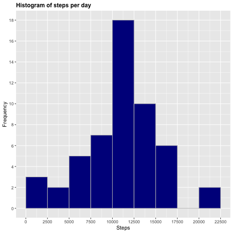

Histogram of the total number of steps taken each day

```r
# draw the histogram
png("hist1.png")
g <- ggplot(StepsPerDay, aes(Steps))
g+geom_histogram(boundary=0, binwidth=2500, col="grey", fill="darkblue") + ggtitle("Histogram of steps per day")+xlab("Steps")+ylab("Frequency")+theme(plot.title = element_text(face="bold", size=12))+scale_x_continuous(breaks=seq(0,25000,2500))+scale_y_continuous(breaks=seq(0,18,2))
dev.off()
```

## What is mean total number of steps taken per day?

**3. Mean and median number of steps taken each day.**

```r
# Mean
mean(StepsPerDay$Steps, na.rm=TRUE)
```

```
## [1] 10766.19
```

```r
#Median
median(StepsPerDay$Steps, na.rm=TRUE)
```

```
## [1] 10765
```

## What is the average daily activity pattern?

**4. Time series plot of the average number of steps taken**

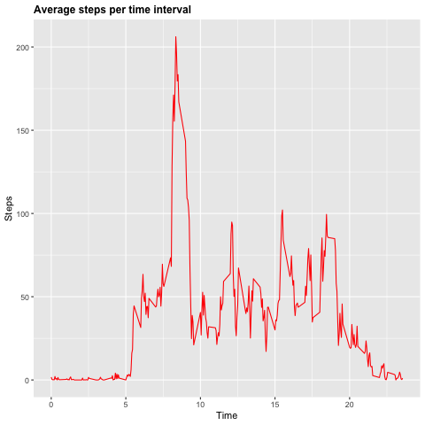

Time series

```r
# create table with steps per time
StepsPerTime <- aggregate(steps~interval,data=activityData,FUN=mean,na.action=na.omit)

# variable time (more comprensible for the graph axis)
StepsPerTime$time <- StepsPerTime$interval/100

# draw the line plot
png("plot1.png")
h <- ggplot(StepsPerTime, aes(time, steps))
h+geom_line(col="red")+ggtitle("Average steps per time interval")+xlab("Time")+ylab("Steps")+theme(plot.title = element_text(face="bold", size=12))
dev.off()
```

## Imputing missing values

**6. Code to describe and show a strategy for imputing missing data.**  
Total number of missing values in the dataset

```r
# table for dplyr
ACT <- tbl_df(activityData)
# find the column
ACT %>% filter(is.na(steps)) %>% summarize(missing_values = n())
```

```
## # A tibble: 1 x 1
##   missing_values
##            <int>
## 1           2304
```

Replace missing values  
The rounded values of the average 5-minute interval is used to replace the NA values.  
CompleteSteps is the new column without missing values.

```r
# values for NA are imputed in a new column
activityData$CompleteSteps <- ifelse(is.na(activityData$steps), round(StepsPerTime$steps[match(activityData$interval, StepsPerTime$interval)],0), activityData$steps)
```

New dataset that is equal to the original dataset but with the missing data filled in.  
The first ten values of the new dataset are shown below.

```r
# new dataset activityFull
activityFull <- data.frame(steps=activityData$CompleteSteps, interval=activityData$interval, date=activityData$date)
# see first 10 values of the new dataset
head(activityFull, n=10)
```

```
##    steps interval       date
## 1      2        0 2012-10-01
## 2      0        5 2012-10-01
## 3      0       10 2012-10-01
## 4      0       15 2012-10-01
## 5      0       20 2012-10-01
## 6      2       25 2012-10-01
## 7      1       30 2012-10-01
## 8      1       35 2012-10-01
## 9      0       40 2012-10-01
## 10     1       45 2012-10-01
```

**7. Histogram of the total number of steps taken each day after missing values are imputed.**

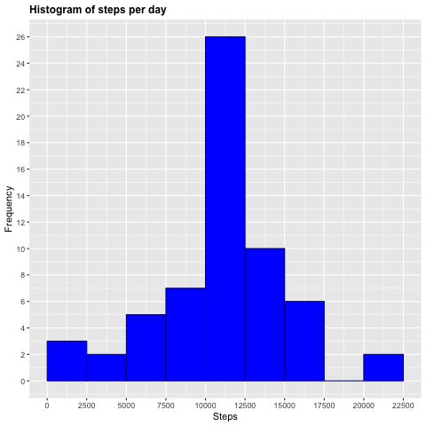

Histogram of the total number of steps taken each day with missing data filled in

```r
# prepare data
StepsPerDayFull <- aggregate(activityFull$steps, list(activityFull$date), FUN=sum)
colnames(StepsPerDayFull) <- c("Date", "Steps")
# draw the histogram
png("hist2.png")
g <- ggplot(StepsPerDayFull, aes(Steps))
g+geom_histogram(boundary=0, binwidth=2500, col="darkblue", fill="blue")+ggtitle("Histogram of steps per day")+xlab("Steps")+ylab("Frequency")+theme(plot.title = element_text(face="bold", size=12))+scale_x_continuous(breaks=seq(0,25000,2500))+scale_y_continuous(breaks=seq(0,26,2))
dev.off()
```

Mean and median total number of steps taken per day with the missing values filled in.

```r
# Mean
mean(StepsPerDayFull$Steps)
```

```
## [1] 10765.64
```

```r
#Median
median(StepsPerDayFull$Steps)
```

```
## [1] 10762
```

## Are there differences in activity patterns between weekdays and weekends?

**8. Panel plot comparing the average number of steps taken per 5-minute interval across weekdays and weekends.**

New variables for weekend and weekdays.

```r
# Create variable with date in correct format
activityFull$RealDate <- as.Date(activityFull$date, format = "%Y-%m-%d")
# create a variable with weekdays name
activityFull$weekday <- weekdays(activityFull$RealDate)
# create a new variable indicating weekday or weekend
activityFull$DayType <- ifelse(activityFull$weekday=='Saturday' | activityFull$weekday=='Sunday', 'weekend','weekday')
# see first 10 values
head(activityFull, n=10)
```

```
##    steps interval       date   RealDate weekday DayType
## 1      2        0 2012-10-01 2012-10-01  Monday weekday
## 2      0        5 2012-10-01 2012-10-01  Monday weekday
## 3      0       10 2012-10-01 2012-10-01  Monday weekday
## 4      0       15 2012-10-01 2012-10-01  Monday weekday
## 5      0       20 2012-10-01 2012-10-01  Monday weekday
## 6      2       25 2012-10-01 2012-10-01  Monday weekday
## 7      1       30 2012-10-01 2012-10-01  Monday weekday
## 8      1       35 2012-10-01 2012-10-01  Monday weekday
## 9      0       40 2012-10-01 2012-10-01  Monday weekday
## 10     1       45 2012-10-01 2012-10-01  Monday weekday
```

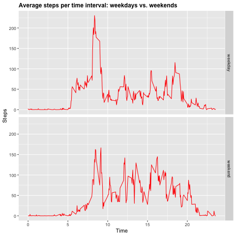

Two time series plot of the 5-minute interval

```r
# create table with steps per time across weekdaydays or weekend days
StepsPerTimeDT <- aggregate(steps~interval+DayType,data=activityFull,FUN=mean,na.action=na.omit)
# variable time (more comprensible for the graph axis)
StepsPerTimeDT$time <- StepsPerTime$interval/100

# draw the line plot
png("plot2.png")
j <- ggplot(StepsPerTimeDT, aes(time, steps))
j+geom_line(col="red")+ggtitle("Average steps per time interval: weekdays vs. weekends")+xlab("Time")+ylab("Steps")+theme(plot.title = element_text(face="bold", size=12))+facet_grid(DayType ~ .)
dev.off()
```